# metaRbolomics dependencies

Steffen Neumann

September 08, 2019

# Libraries and settings

```r
options("repos" = list(CRAN="http://cran.rstudio.com/"))

library(devtools)   # for revdp()
library(igraph)     # for graph_from_edgelist/( and simplify() )
library(visNetwork) # for visNetwork() and friends
library(networkD3)  # for saveNetwork()
library(chromote)   # for default_chromote_object()
library(webshot2)   # for webshot()
library(png)        # For displaying an image
library(dplyr)
library(purrr)
source("revDepNetHelper.R")

set_default_chromote_object(Chromote$new(browser = Chrome$new(args = "--no-sandbox")))
```

# Read package names from our table

```r
reviewTables <- read.delim("AllMetaRbolomicsTables.csv", stringsAsFactors = FALSE)
reviewPkgs <- reviewTables[,"Package"]

pkgs <- reviewPkgs
```

# Get reverse dependencies

## For CRAN and BioC packages

```r
el <- sapply(pkgs, function(pkg) {
  rd <- revdep(pkg, dependencies = c("Depends", "Imports", "LinkingTo"),
               recursive = FALSE, ignore = NULL, bioconductor = TRUE)
  as.matrix(cbind(Package=rep(pkg, length.out=length(rd)), ReverseDep=rd))
})
el <- do.call(rbind, el)
```

## For GitHub and GitLab

The above `devtools::revdep` cannot read from GitHub/GitLab repositories. We have a helper function that downloads and parses the DESCRIPTION file from GitHub/GitLab. Since we cannot get reverse dependencies directly for GitHub/GitLab packages, those packages they are only used as additional reverse depedencies for the CRAN/BioC packages.

```r
gitdeps_reverse <- reviewTables %>%
                      mutate(dep_tree = map(Code_link, get_git_deps)) %>%
                      pull(dep_tree) %>%
                      bind_rows() %>%
                      filter(Dep %in% el[,"Package"]) %>%
                      rename(Package = Dep, ReverseDep = Package) %>%
                      as.matrix()
el <- rbind(el, gitdeps_reverse)
```

# Building dependency network

From the total, 68 packages had at least one such reverse dependency.

```r
## Remove packages with most reverse dependencies
## which would dominate the network

el <- el[! el[,"Package"] %in% c("Rcpp", "igraph", "vegan", "caret", "rJava", "reticulate"), ]

## Create graph, and simplify redundancy
g <- graph_from_edgelist(el, directed = TRUE)
g <- igraph::simplify(g, remove.multiple = TRUE, remove.loops = TRUE)

# get data and plot :
data <- toVisNetworkData(g)

data$nodes <- cbind(data$nodes,
                    font.size=30,
                    color.background = ifelse(data$nodes[,"id"] %in% pkgs ,
                           rgb(0, 0, 200, 128, max = 255),
                           rgb(0, 200, 0, 128, max = 255)))

vn <- visNetwork(nodes = data$nodes,
                 edges = data$edges,
                 width=1000, height=1000) %>%
  visPhysics(timestep = 0.3,
             barnesHut = list(centralGravity=0.35,
                              springLength = 95)) %>%
  visOptions(highlightNearest = TRUE)

vn
```

[interactive chart not shown]

Figure 2: Dependency network of R packages. Shown in blue are packages mentioned in the review. Edges connect to packages that depend on another package, as long as that is in CRAN or BioC. Green nodes correspond to packages in CRAN or BioC not covered in the review. Not shown are 1) infrastructure packages e.g. rJava, Rcpp 2) packages from the review without reverse dependencies and 3) data packages. Some packages from the review are not in current versions of CRAN or BioC. An interactive version of this figure is available from https://sneumann.github.io/metaRbolomics/revDepNet.html.

# Save network plot

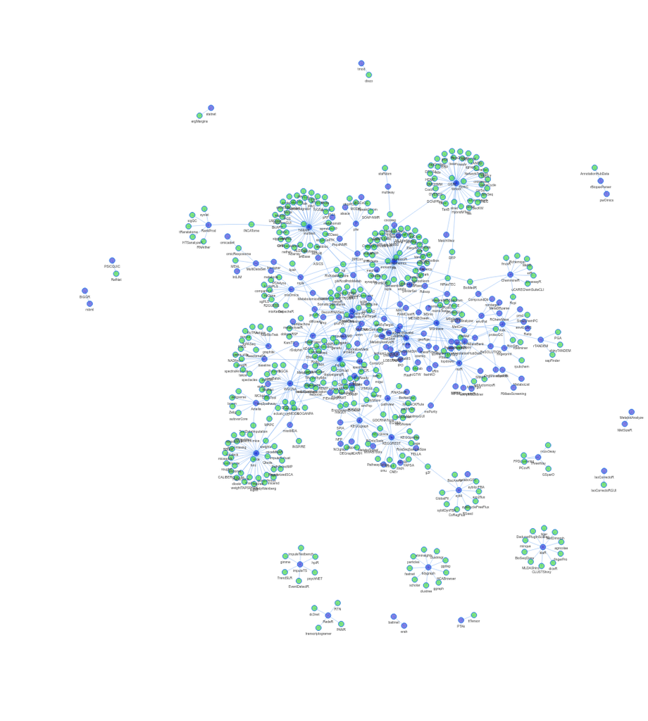

```r
saveNetwork(vn, "vn.html")
webshot("vn.html", "revDepNet-60.png", delay = 60)
```

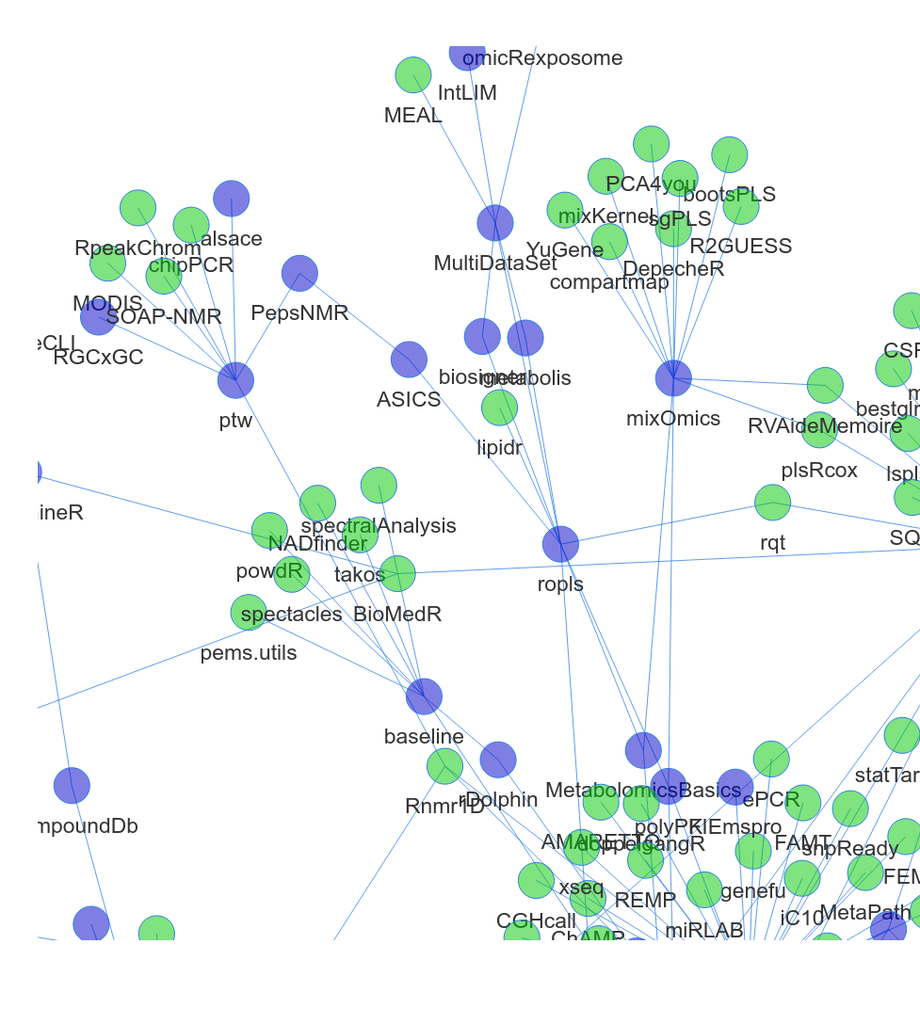

```r
vnZoom <- visNetwork(nodes = data$nodes,
                 edges = data$edges,
                 width=1000, height=1000) %>%
    visIgraphLayout()%>%
    visEvents(type="once", startStabilizing = 'function() {
              this.fit({nodes:["ptw", "Rnmr1D", "RpeakChrom", "alsace",
                               "PepsNMR", "ASICS", "MODIS", "RGCxGC"]})
            }')
saveNetwork(vnZoom, "vnZoom.html")
webshot("vnZoom.html", "revDepNet-zoom.png", delay = 5)
```

# Notes

The source code for this page is on GitHub at github.com/sneumann/metaRbolomics

The HTML output is shown at sneumann.github.io/metaRbolomics/revDepNet.html

and sneumann.github.io/metaRbolomics/vn.html (Caveat: long rendering time, blank page without any visible progress)

This page was created with the following packages:

```
## R Under development (unstable) (2019-03-05 r76199)
## Platform: x86_64-pc-linux-gnu (64-bit)
## Running under: Ubuntu 18.04.3 LTS
##
## Matrix products: default
## BLAS: /vol/R/R-devel/lib/R/lib/libRblas.so
## LAPACK: /vol/R/R-devel/lib/R/lib/libRlapack.so
##
## locale:
##  [1] LC_CTYPE=en_US.UTF-8       LC_NUMERIC=C
##  [3] LC_TIME=en_US.UTF-8        LC_COLLATE=en_US.UTF-8
##  [5] LC_MONETARY=en_US.UTF-8    LC_MESSAGES=en_US.UTF-8
##  [7] LC_PAPER=en_US.UTF-8       LC_NAME=C
##  [9] LC_ADDRESS=C               LC_TELEPHONE=C
## [11] LC_MEASUREMENT=en_US.UTF-8 LC_IDENTIFICATION=C
##
## attached base packages:
## [1] stats     graphics  grDevices utils     datasets  methods   base
##
## other attached packages:
##  [1] desc_1.2.0          purrr_0.3.2         dplyr_0.8.3
##  [4] png_0.1-7           webshot2_0.0.0.9000 chromote_0.0.0.9001
##  [7] networkD3_0.4       visNetwork_2.0.6    igraph_1.2.4.1
## [10] usethis_1.5.0       devtools_2.0.2
##
## loaded via a namespace (and not attached):
##  [1] Rcpp_1.0.1          BiocManager_1.30.4  pillar_1.4.0
##  [4] later_0.8.0.9003    compiler_3.6.0      prettyunits_1.0.2
##  [7] remotes_2.0.4       tools_3.6.0         testthat_2.1.1
## [10] digest_0.6.18       pkgbuild_1.0.3      pkgload_1.0.2
## [13] tibble_2.1.1        jsonlite_1.6        evaluate_0.13
## [16] memoise_1.1.0       pkgconfig_2.0.2     rlang_0.4.0
## [19] cli_1.1.0           curl_3.3            yaml_2.2.0
## [22] xfun_0.7            fastmap_1.0.0       withr_2.1.2
## [25] stringr_1.4.0       knitr_1.22          fs_1.3.1
## [28] htmlwidgets_1.3     tidyselect_0.2.5    websocket_1.0.0
## [31] rprojroot_1.3-2     glue_1.3.1          R6_2.4.0
## [34] processx_3.3.1      rmarkdown_1.12      sessioninfo_1.1.1
## [37] callr_3.2.0         magrittr_1.5        codetools_0.2-16
## [40] promises_1.0.1.9002 backports_1.1.4     ps_1.3.0
## [43] htmltools_0.3.6     assertthat_0.2.1    stringi_1.4.3
## [46] crayon_1.3.4
```